# Doctor’s Appointment No-Shows Analysis

Will Koehrsen

April 9, 2017

# Abstract

Doctor’s appointment no-shows are a serious issue in the public health care field. Missed appointments are associated with poorer patient outcomes and cost the [health care system in the US nearly $200 each.](https://www.ncbi.nlm.nih.gov/pmc/articles/PMC4714455/) Therefore it comes as no small surprise that reducing the rate of no-shows has become a priority in the United States and around the world. [Numerous studies](https://www.ncbi.nlm.nih.gov/pmc/articles/PMC3962267/) have been undertaken in order to determine the most effective means of reducing rates of absenteeism at with varying degrees of success. The first step to solving the problem of missed appointments is identifying why a patient skips a scheduled visit in the first place. What trends are there among patients with higher absence rates? Are there demographic indicators or perhaps time-variant relationships hiding in the data? Ultimately, it was these questions that drove my exploratory data analysis. I was curious as to the reasons behind missed appointments, and wanted to examine the data to identify any trends present. I choose this problem because I believe it is an excellent example of how data science and analysis can reveal relationships which can be implemented in the real-world to the benefit of society.

## Introduction to Dataset

I wanted to choose a dataset that was both relatable and could be used to make smarter decisions. Therefore, I decided to work with [medical appointment no shows data available on Kaggle](https://www.kaggle.com/joniarroba/noshowappointments). This dataset is drawn from 300,000 primary physcian visits in Brazil across 2014 and 2015. The information about the appointment was automatically coded when the patient scheduled the appointment and then the patient was marked as having either attended or not. The information about the appointment included demongraphic data, time data, and conditions concerning the reason for the visit.

There were a total of 14 variables I included from the original data. The variables are as follows

1. **Age**: integer age of patient
2. **Gender**: M or F
3. **AppointmentReservationDate**: date and time appointment was made
4. **AppointmentDate**: date of appointment without time
5. **DayOfTheWeek**: day of the week of appointment
6. **Status**: Show-up or No-Show
7. **Diabetes**: 0 or 1 for condition (1 means patient was scheduled to treat condition)
8. **Alcoholism**: 0 or 1 for condition
9. **Hypertension**: 0 or 1 for condition
10. **Smoker**: 0 or 1 for smoker / non-smoker
11. **Scholarship**: 0 or 1 indicating whether the family of the patient takes part in the [Bolsa Familia Program](http://www.worldbank.org/en/news/opinion/2013/11/04/bolsa-familia-Brazil-quiet-revolution), an intiative that provides families with small cash transfers in exchange for keeping children in school and completing health care visits
12. **Tuberculosis**: 1 or 0 for condition
13. **SMSReminder**: 0 ,1 ,2 for number of text message reminders sent to patient about appointment
14. **WaitingTime**: integer number of days between when the appointment was made and when the appointment took place.

## Data Organization and Cleaning

Let’s take a look at the structure of the dataframe to identify cleaning/organizing that may need to be performed.

```r
str(no_shows)
```

```
## 'data.frame':    300000 obs. of  14 variables:
##  $ Age                        : int  19 24 4 5 38 5 46 4 20 51 ...
##  $ Gender                     : Factor w/ 2 levels "F","M": 2 1 1 2 2 1 1 1 1 1 ...
##  $ AppointmentRegistrationDate: Factor w/ 295425 levels "2013-05-29T15:14:11Z",..: 152112 248200 23071 87268 274612 71585 225305 244749 125184 70354 ...
##  $ AppointmentDate            : Factor w/ 534 levels "2014-01-02T00:00:00Z",..: 290 440 36 164 490 152 408 442 232 125 ...
##  $ DayOfTheWeek               : Factor w/ 7 levels "Friday","Monday",..: 7 7 6 5 6 6 6 1 6 6 ...
##  $ Status                     : Factor w/ 2 levels "No-Show","Show-Up": 2 2 2 2 2 1 2 2 2 2 ...
##  $ Diabetes                   : int  0 0 0 0 0 0 0 0 0 1 ...
##  $ Alcoholism                 : int  0 0 0 0 0 0 0 0 0 0 ...
##  $ Hypertension               : int  0 0 0 0 0 0 0 0 0 1 ...
##  $ Smoker                     : int  0 0 0 0 0 0 0 0 0 0 ...
##  $ Scholarship                : int  0 0 0 0 0 0 0 1 0 0 ...
##  $ Tuberculosis               : int  0 0 0 0 0 0 0 0 0 0 ...
##  $ SmsReminder                : int  0 0 0 1 1 1 1 1 0 1 ...
##  $ WaitingTime                : int  29 1 1 15 6 35 18 14 14 4 ...
```

From the structure of the dataframe, I can see there is some data housekeeping that needs to be done. First, I want to change the Status variable into an integer 0 or 1. A value of 1 will indicate that the patient did not show up as I am concerned with the variables that are most strongly correlated with a missed appointment. Moreover, I need to convert the registration date and the appointment date to date objects. I decided not to maintain the time (hours:minutes:seconds) associated with the registration date for the apointment although it was available (time of day was not available for the appointment date). I converted both the appointment registration date and appointment date to date objects so I could investigate seasonal and time patterns in the data.

```r
# Create numeric factors out of the two levels in status field
no_shows['Status'] <- lapply(no_shows['Status'], factor,  levels=c("Show-Up", "No-Show"), labels = c(0, 1))
# Change the factors in the the status column into 1: patient missed appointment and 0: patient attended appointment
no_shows$Status <- as.integer(as.character(no_shows$Status))

# Remove characters from dates and convert into date objects
no_shows$AppointmentDate <-gsub(pattern = "[A-Z]", replacement = " ", x = no_shows$AppointmentDate)
no_shows$AppointmentRegistrationDate <- gsub(pattern = "[A-Z]", replacement = " ", x = no_shows$AppointmentRegistrationDate)
no_shows$AppointmentDate <- as.Date(no_shows$AppointmentDate)
no_shows$AppointmentRegistrationDate <- as.Date(no_shows$AppointmentRegistrationDate)
str(no_shows)
```

```
## 'data.frame':    300000 obs. of  14 variables:
##  $ Age                        : int  19 24 4 5 38 5 46 4 20 51 ...
##  $ Gender                     : Factor w/ 2 levels "F","M": 2 1 1 2 2 1 1 1 1 1 ...
##  $ AppointmentRegistrationDate: Date, format: "2014-12-16" "2015-08-18" ...
##  $ AppointmentDate            : Date, format: "2015-01-14" "2015-08-19" ...
##  $ DayOfTheWeek               : Factor w/ 7 levels "Friday","Monday",..: 7 7 6 5 6 6 6 1 6 6 ...
##  $ Status                     : int  0 0 0 0 0 1 0 0 0 0 ...
##  $ Diabetes                   : int  0 0 0 0 0 0 0 0 0 1 ...
##  $ Alcoholism                 : int  0 0 0 0 0 0 0 0 0 0 ...
##  $ Hypertension               : int  0 0 0 0 0 0 0 0 0 1 ...
##  $ Smoker                     : int  0 0 0 0 0 0 0 0 0 0 ...
##  $ Scholarship                : int  0 0 0 0 0 0 0 1 0 0 ...
##  $ Tuberculosis               : int  0 0 0 0 0 0 0 0 0 0 ...
##  $ SmsReminder                : int  0 0 0 1 1 1 1 1 0 1 ...
##  $ WaitingTime                : int  29 1 1 15 6 35 18 14 14 4 ...
```

Based on the updated structure of the dataframe, it looks like I am on the right track but I still have a couple more modifications to make to the dataframe. I will create month, year, and day fields for the appointment and also rename the colmuns to a more consistent and readable format.

```r
# Extract month, year, and day from appointment date and create new columns
no_shows <-transform(no_shows, month = format(AppointmentDate, "%m"))
no_shows <- transform(no_shows, year = format(AppointmentDate, "%Y"))
no_shows <- transform(no_shows, day = format(AppointmentDate, "%d"))

no_shows$year <- as.integer(as.character(no_shows$year))
no_shows$month <- as.integer(as.character(no_shows$month))
no_shows$day <- as.integer(as.character(no_shows$day))

# Clarify and simply column names
no_shows <- plyr::rename(no_shows, c("Age" = "age",
                               "Gender" = "gender",
                               "AppointmentRegistrationDate" = "appt_reg_date",
                               "AppointmentDate" = "appt_date",
                               "DayOfTheWeek" = "weekday",
                               "Status" = "status",
                               "Diabetes" = "diabetes",
                               "Alcoholism" = "alcoholism",
                               "Hypertension" = "hypertension",
                               "Smoker" = "smoker",
                               "Scholarship" = "welfare",
                               "Tuberculosis" = "tuberculosis",
                               "SmsReminder" = "sms_reminder",
                               "WaitingTime" = "wait",
                               "month" = "appt_month",
                               "year" = "appt_year",
                               "day" = "appt_day"))
```

That should about do it for the structure of the main dataframe. I am also concerned with missing/corrupted data, so I will look at the summary of each field to see if any obvious errors or outliers are present in the data.

```r
# Look at the summary of statistics for the dataframe
summary(no_shows)
```

```
##       age         gender     appt_reg_date          appt_date
##  Min.   : -2.00   F:200505   Min.   :2013-05-29   Min.   :2014-01-02
##  1st Qu.: 19.00   M: 99495   1st Qu.:2014-06-24   1st Qu.:2014-07-04
##  Median : 38.00              Median :2014-12-03   Median :2014-12-16
##  Mean   : 37.81              Mean   :2014-12-14   Mean   :2014-12-28
##  3rd Qu.: 56.00              3rd Qu.:2015-06-11   3rd Qu.:2015-06-25
##  Max.   :113.00              Max.   :2015-12-29   Max.   :2015-12-30
##
##       weekday          status          diabetes         alcoholism
##  Friday   :52771   Min.   :0.0000   Min.   :0.00000   Min.   :0.00000
##  Monday   :59298   1st Qu.:0.0000   1st Qu.:0.00000   1st Qu.:0.00000
##  Saturday : 1393   Median :0.0000   Median :0.00000   Median :0.00000
##  Sunday   :    6   Mean   :0.3024   Mean   :0.07797   Mean   :0.02501
##  Thursday :60262   3rd Qu.:1.0000   3rd Qu.:0.00000   3rd Qu.:0.00000
##  Tuesday  :62775   Max.   :1.0000   Max.   :1.00000   Max.   :1.00000
##  Wednesday:63495
##   hypertension        smoker           welfare        tuberculosis
##  Min.   :0.0000   Min.   :0.00000   Min.   :0.0000   Min.   :0.00000
##  1st Qu.:0.0000   1st Qu.:0.00000   1st Qu.:0.0000   1st Qu.:0.00000
##  Median :0.0000   Median :0.00000   Median :0.0000   Median :0.00000
##  Mean   :0.2159   Mean   :0.05237   Mean   :0.0969   Mean   :0.00045
##  3rd Qu.:0.0000   3rd Qu.:0.00000   3rd Qu.:0.0000   3rd Qu.:0.00000
##  Max.   :1.0000   Max.   :1.00000   Max.   :1.0000   Max.   :1.00000
##
##   sms_reminder         wait          appt_month       appt_year
##  Min.   :0.0000   Min.   :  1.00   Min.   : 1.000   Min.   :2014
##  1st Qu.:0.0000   1st Qu.:  4.00   1st Qu.: 4.000   1st Qu.:2014
##  Median :1.0000   Median :  8.00   Median : 7.000   Median :2014
##  Mean   :0.5742   Mean   : 13.84   Mean   : 6.584   Mean   :2014
##  3rd Qu.:1.0000   3rd Qu.: 20.00   3rd Qu.:10.000   3rd Qu.:2015
##  Max.   :2.0000   Max.   :398.00   Max.   :12.000   Max.   :2015
##
##     appt_day
##  Min.   : 1.00
##  1st Qu.: 9.00
##  Median :16.00
##  Mean   :15.89
##  3rd Qu.:23.00
##  Max.   :31.00
##
```

The summary of the no_shows dataframe reveals plenty of intriguing information as well as several errors that need to be corrected. Right away, it is clear that an age of -2 is not correct, and 113 is stretching the boundaries. However, looking at the [oldest people in the world](https://en.wikipedia.org/wiki/List_of_the_verified_oldest_people), it is plausible that 113 could be a correct age. I will filter out any negative ages and create a histogram of ages to see if there are a significant amount of outliers at the upper end. Moreover, this data summary shows that **30.24%** of appointments are missed based on the mean for the status field. The rates for the various patient conditions can also be seen, and the most commonly coded reason for an appointment is **hypertension at nearly 22% of visits**. Also, the weekends appear to be a very unpopular time for doctor’s appointments in Brazil, or perhaps the clinics from which this data was drawn are not open on the weekend. Either way, I will need to keep the small sample size of appointments on the weekend in mind when I perform an analysis by weekday.

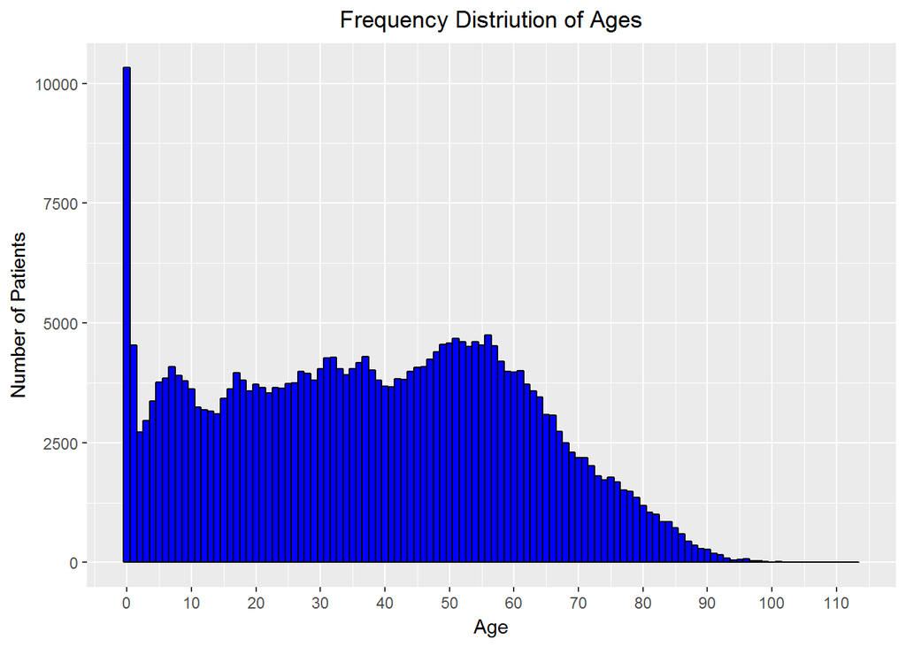

```r
# Filter out ages below 0
no_shows <- filter(no_shows, age >= 0)
# Set all titles in plots to be centered
theme_update(plot.title=element_text(hjust = 0.5))

# Create histogram of ages
qplot(x = age, data = no_shows, color = I('black') , fill = I('blue'), binwidth = 1) + theme(legend.position="None") +
  labs(x='Age', y="Number of Patients", title='Frequency Distriution of Ages') + scale_x_continuous(breaks=seq(0,110, 10))
```

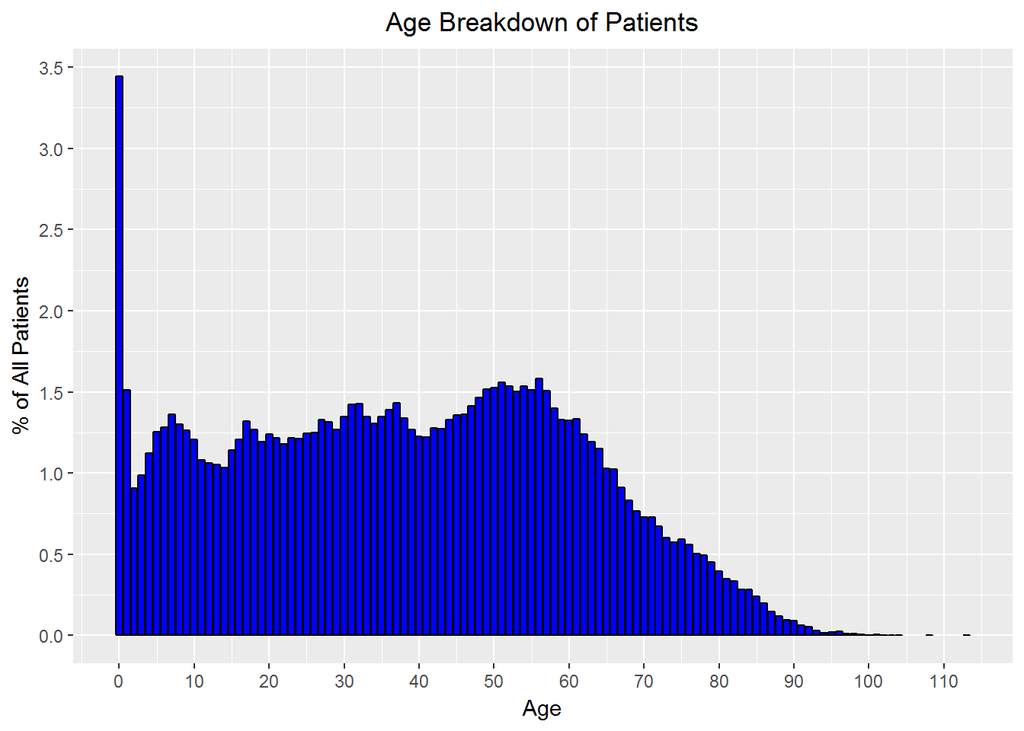

```r
# Group the main dataframe by age and calculate the number of occurences of each age
no_shows_by_age <- group_by(no_shows, age)
no_shows_by_age <- dplyr::summarize(no_shows_by_age,
                          n = n())

# Add field with percentage of all patients
no_shows_by_age$pct <- 100* no_shows_by_age$n / nrow(no_shows)

# Create the bar plot
ggplot(aes(x = age, y = pct), data = no_shows_by_age) + geom_bar(stat='identity', color = 'black', fill = 'blue') +
  labs(x = 'Age', y= '% of All Patients', title='Age Breakdown of Patients') + scale_y_continuous(breaks=seq(0,4,0.50)) +
  scale_x_continuous(breaks=seq(0,110, 10))
```

```r
# Calculate percentage of patients with an age of 0
nrow(subset(no_shows, age == 0)) / nrow(no_shows) * 100
```

```
## [1] 3.442069
```

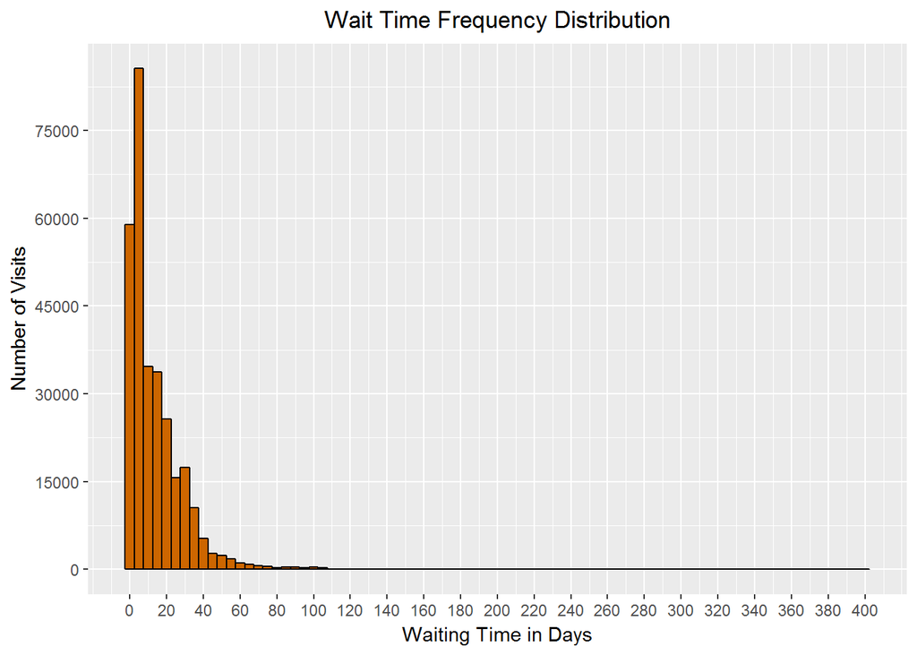

```r
# Create histogram for waiting time
qplot(x = wait, data = no_shows, color = I('black'), fill= I('darkorange3'), binwidth = 5) + labs(x='Waiting Time in Days', y = 'Number of Visits', title='Wait Time Frequency Distribution') + scale_y_continuous(breaks=seq(0,90000, 15000)) + scale_x_continuous(breaks=seq(0, 400, 20))
```

Based on the summary statistics of the dataframe, the longest waiting time was 398 days, with a median of 8 days, and a mean of 13.84 days. From the histogram and the statistics, it is clear that there are a small number of patients at the upper end of the distribution who schedule their appointment very far in advance. I wonder if the 398 days is accidentally a mistake that occured when someone choose the wrong year for their appointment! The graph is certainly long-tailed and positively skewed with a few extreme outliers at the upper limit.

```r
# Subset the data and count the rows
nrow(subset(no_shows, wait > 365))
```

```
## [1] 1
```

```r
nrow(subset(no_shows, wait > 180))
```

```
## [1] 136
```

It appears there is only one patient with a waiting time over one year and just over 100 (out of 300000) with a waiting time of over six months. I will exclude the patient with the waiting time over one year, but I will treat the others as good but extreme data. Here is a version of the histogram that better represents the wait time for most patients.

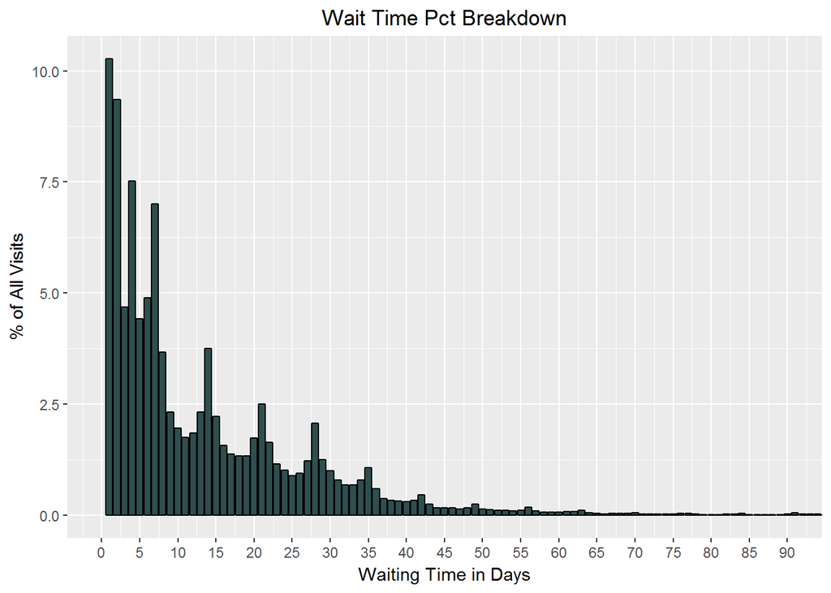

```r
# Remover wait time over one year
no_shows <- filter(no_shows, wait < 365)
# Create a new dataframe by grouping and find the statistics
no_shows_by_wait <- group_by(no_shows, wait)
no_shows_by_wait <- dplyr::summarize(no_shows_by_wait,
                                     n = n())

# Find the wait time percentage of all appointments
no_shows_by_wait$pct <- 100 * no_shows_by_wait$n / nrow(no_shows)

# Plot the data as a bar plot
ggplot(aes(x = wait, y = pct), data = no_shows_by_wait) + geom_bar(stat= 'identity', color = 'black', fill = 'darkslategrey') + labs(x='Waiting Time in Days', y = '% of All Visits', title='Wait Time Pct Breakdown') + coord_cartesian(xlim=c(0,90)) + scale_x_continuous(breaks=seq(0,90,5))
```

As can be seen in the chart, a plurality of patients wait less than 10 days between the scheduling and the date of their appointment. Based on these visualizations, and the summary statistics for the dataframe, I am confident that the data content of the main dataframe is valid. I can now start the exploration phase of exploratory data analysis! It is time to discover the relationships, or lack thereof, between the variables in the data.

## Exploring the Variables

The first step I can take is to find the correlations between all of the columns to see if any stand out as particularly compelling. Of course, I expect that all the trends will not reveal themselves straight away. The [rcorr function](http://math.furman.edu/~dcs/courses/math47/R/library/Hmisc/html/rcorr.html) from the Hmisc library will calculate the Pearson’s correlation coeffient between every field of a dataframe. The [Pearson correlation coefficient](http://www.statisticshowto.com/what-is-the-pearson-correlation-coefficient/), is a measure of how linearly dependent two variables on each other. The coefficient value is between -1 and +1, and two variables that are perfectly linearly correlated will have a value of +1.

```r
# Find correlations between the selected fields (numeric fields only were chosen)
ccs <- as.matrix(no_shows[,c(1, 6:17)])
rcorr(ccs, type='pearson')[1]
```

```
## $r
##                       age        status      diabetes   alcoholism
## age           1.000000000 -0.0998202935  0.2944338024  0.071154729
## status       -0.099820293  1.0000000000 -0.0310714860  0.025460839
## diabetes      0.294433802 -0.0310714860  1.0000000000  0.020540850
## alcoholism    0.071154729  0.0254608393  0.0205408502  1.000000000
## hypertension  0.508124232 -0.0590503365  0.4243405759  0.069892593
## smoker        0.088655755  0.0240571816  0.0386765264  0.385781735
## welfare      -0.108530030  0.0410330258 -0.0272531025  0.039613742
## tuberculosis  0.001370069  0.0038227588  0.0014503981  0.045920089
## sms_reminder -0.053542137 -0.0001640972 -0.0323315971 -0.019218484
## wait         -0.004255935  0.0667358413 -0.0233943518 -0.025409902
## appt_month   -0.002719924  0.0147490725 -0.0063219219 -0.001248228
## appt_year     0.006317845  0.0035064416 -0.0091518238 -0.001597081
## appt_day     -0.008120785  0.0068805055  0.0006779103 -0.001206586
##              hypertension       smoker       welfare  tuberculosis
## age           0.508124232  0.088655755 -0.1085300297  0.0013700685
## status       -0.059050336  0.024057182  0.0410330258  0.0038227588
## diabetes      0.424340576  0.038676526 -0.0272531025  0.0014503981
## alcoholism    0.069892593  0.385781735  0.0396137424  0.0459200889
## hypertension  1.000000000  0.075974628 -0.0324227996 -0.0046397443
## smoker        0.075974628  1.000000000  0.0640681833  0.0253492817
## welfare      -0.032422800  0.064068183  1.0000000000  0.0079264184
## tuberculosis -0.004639744  0.025349282  0.0079264184  1.0000000000
## sms_reminder -0.045195710 -0.010710954  0.0157913826 -0.0067648315
## wait         -0.043980602 -0.030264340 -0.0182978343 -0.0054302728
## appt_month   -0.011527045 -0.000968976 -0.0012980073 -0.0011103459
## appt_year    -0.018014729 -0.006522796 -0.0059216563 -0.0008486644
## appt_day     -0.003153301 -0.002948875 -0.0003028459 -0.0015791535
##               sms_reminder         wait   appt_month     appt_year
## age          -0.0535421371 -0.004255935 -0.002719924  0.0063178446
## status       -0.0001640972  0.066735841  0.014749072  0.0035064416
## diabetes     -0.0323315971 -0.023394352 -0.006321922 -0.0091518238
## alcoholism   -0.0192184839 -0.025409902 -0.001248228 -0.0015970806
## hypertension -0.0451957099 -0.043980602 -0.011527045 -0.0180147290
## smoker       -0.0107109537 -0.030264340 -0.000968976 -0.0065227957
## welfare       0.0157913826 -0.018297834 -0.001298007 -0.0059216563
## tuberculosis -0.0067648315 -0.005430273 -0.001110346 -0.0008486644
## sms_reminder  1.0000000000  0.238497972 -0.109772936  0.1402036250
## wait          0.2384979725  1.000000000  0.031398434  0.0498213135
## appt_month   -0.1097729355  0.031398434  1.000000000 -0.0166805908
## appt_year     0.1402036250  0.049821313 -0.016680591  1.0000000000
## appt_day      0.0317807533  0.050786920 -0.064924933  0.0103808455
##                   appt_day
## age          -0.0081207855
## status        0.0068805055
## diabetes      0.0006779103
## alcoholism   -0.0012065860
## hypertension -0.0031533011
## smoker       -0.0029488748
## welfare      -0.0003028459
## tuberculosis -0.0015791535
## sms_reminder  0.0317807533
## wait          0.0507869199
## appt_month   -0.0649249330
## appt_year     0.0103808455
## appt_day      1.0000000000
```

Well, from those correlation values, there are no standouts that are strong linear predictors of whether or not a patient will miss a visit. However, I still think there are meaningful relationships to extract from the data. My approach will be to group the data by various fields and then determine if the average absence rate shows a relationship with the fields. The first group of variables I will look at will be those associated with the time-variability of the appointment date.

### Date of Appointment

To start off the time analysis, I will want to look at absence rate by month of the year. I first needed to group the appointments by month of year and then find the average absence rate for each month.

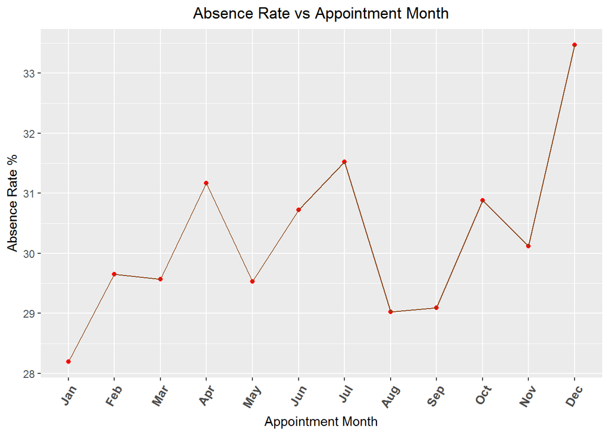

```r
# Create a new dataframe grouped by month and calculate the statistics
no_shows_by_month <- group_by(no_shows, appt_month)
no_shows_by_month <- dplyr::summarize(no_shows_by_month,
                                      absence_rate = mean(status),
                                      n = n())

# Structure labels for plotting and create the No-Show rate vs month plot
month_labels = c('Jan', 'Feb', 'Mar', 'Apr', 'May', 'Jun', 'Jul' , 'Aug', 'Sep', 'Oct', 'Nov' , 'Dec')
no_shows_by_month$month_name <- month_labels
no_shows_by_month$month_name <- factor(no_shows_by_month$month_name, levels=unique(no_shows_by_month$month_name))
ggplot(aes(x = month_name, y = 100* absence_rate), data = no_shows_by_month) + geom_point(color = 'red')  +
  labs(x = 'Appointment Month', y = 'Absence Rate %', title='Absence Rate vs Appointment Month') +               theme(axis.text.x=element_text(angle = 60, face = "bold", size = 10, hjust=1)) +
  geom_line(group =1, color = 'chocolate4')
```

```r
cor.test(no_shows_by_month$absence_rate, no_shows_by_month$appt_month)
```

```
##
##  Pearson's product-moment correlation
##
## data:  no_shows_by_month$absence_rate and no_shows_by_month$appt_month
## t = 2.0244, df = 10, p-value = 0.07046
## alternative hypothesis: true correlation is not equal to 0
## 95 percent confidence interval:
##  -0.05031758  0.85003600
## sample estimates:
##       cor
## 0.5391533
```

From the graph and the correlation coefficient, it appears there is a minor relationship between month of the year and absence rate. Missed visits do appear to rise as the year progresses, but with only 12 data points, the 95% confidence interval for the correlation coefficient is quite large (-0.05 to 0.85). I would expect that during the end of the year, people tend to be busier and may miss more appointments. It could also be possible that at the beginning of the year, individuals make resolutions to see the doctor and keep a higher percentage of appointments, but the trend could also be noise. Next, I will create a similar graph, but this time by day of the month.

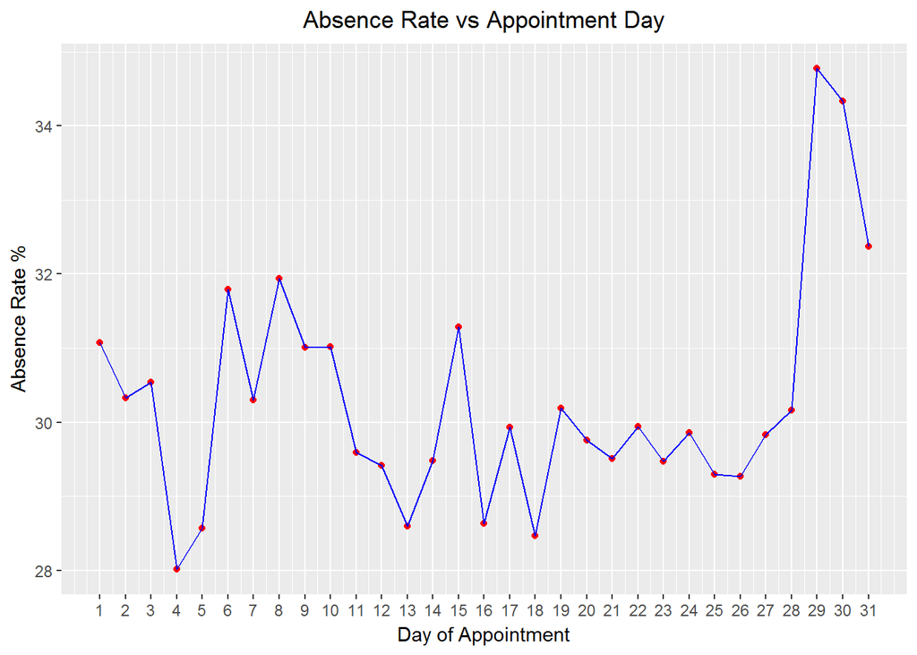

```r
no_shows_by_day <- group_by(no_shows, appt_day)
no_shows_by_day <- dplyr::summarize(no_shows_by_day,
                                    absence_rate = mean(status),
                                    n = n())
ggplot(aes(x = appt_day, y = 100*absence_rate), data = no_shows_by_day) + geom_point(color = 'red')  + labs(x = 'Day of Appointment', y = 'Absence Rate %', title='Absence Rate vs Appointment Day') + scale_x_continuous(breaks=seq(1,31,1)) + geom_line(color='blue')
```

```r
cor.test(no_shows_by_day$appt_day, no_shows_by_day$absence_rate)
```

```
##
##  Pearson's product-moment correlation
##
## data:  no_shows_by_day$appt_day and no_shows_by_day$absence_rate
## t = 1.3753, df = 29, p-value = 0.1796
## alternative hypothesis: true correlation is not equal to 0
## 95 percent confidence interval:
##  -0.1171669  0.5532753
## sample estimates:
##       cor
## 0.2474464
```

Looking at the we can see that there is a very slight positive correlation between day of the month and absence rate but again, the 95% confidence interval spans a wide range of values. To further explore any time variablitity in the data, I can create the same graph by day of the year and broken out by gender.

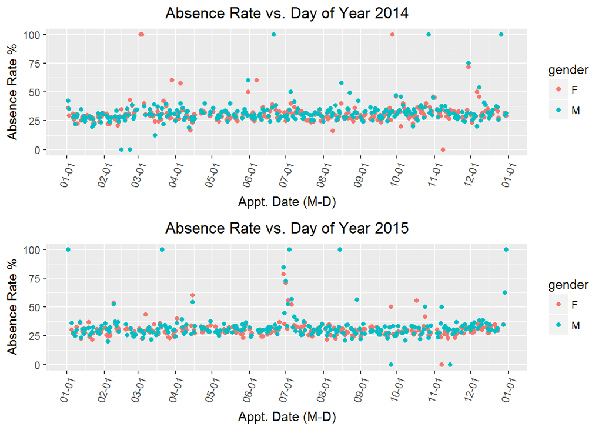

```r
# Load in gridExtra library for multiple plots
suppressMessages(library(gridExtra))

# First plot for 2014
p1 <- ggplot(aes(x = appt_date, y = 100*status), data = subset(no_shows, appt_year == 2014)) + geom_point(aes(color = gender),stat = 'summary', fun.y = mean)  + labs(x = 'Appt. Date (M-D)', y = 'Absence Rate %', title = 'Absence Rate vs. Day of Year 2014') + scale_x_date(date_breaks = "1 month", date_labels = "%m-%d") + theme(axis.text.x  =element_text(angle = 70, hjust = 1))

# Second plot for 2015
p2 <- ggplot(aes(x = appt_date, y = 100*status), data = subset(no_shows, appt_year == 2015)) + geom_point(aes(color = gender),stat = 'summary', fun.y = mean)  +
  labs(x = 'Appt. Date (M-D)', y = 'Absence Rate %', title = 'Absence Rate vs. Day of Year 2015') + scale_x_date(date_breaks = "1 month", date_labels = "%m-%d") + theme(axis.text.x  =element_text(angle = 70, hjust = 1))

grid.arrange(p1, p2, ncol = 1)
```

```r
# Calculate absence rate by gender
100 * mean(no_shows$status[no_shows$gender=='M'])
```

```
## [1] 30.99653
```

```r
100 * mean(no_shows$status[no_shows$gender=='F'])
```

```
## [1] 29.86962
```

From these charts, it appears looks as if there is no correlation betwen the time of year and the absence rate for appointments. Moreover, adding in the gender does not reveal any major descrepancies, although from the calculation, we can see that men on average have a 1% higher absence rate. There are several days for which the absence rate is 1, which bears some more investigation. My idea is that these points might corespond to public holidays. However, I also see that these days are not consistent across the two years, so maybe there are other major events that correspond to an increase in absences. I decided to overlay the holidays to see if that might reveal a relationship. I sourced the holidays based on [public holidays in Brazil](http://www.officeholidays.com/countries/brazil/2015.php) for each respective year.

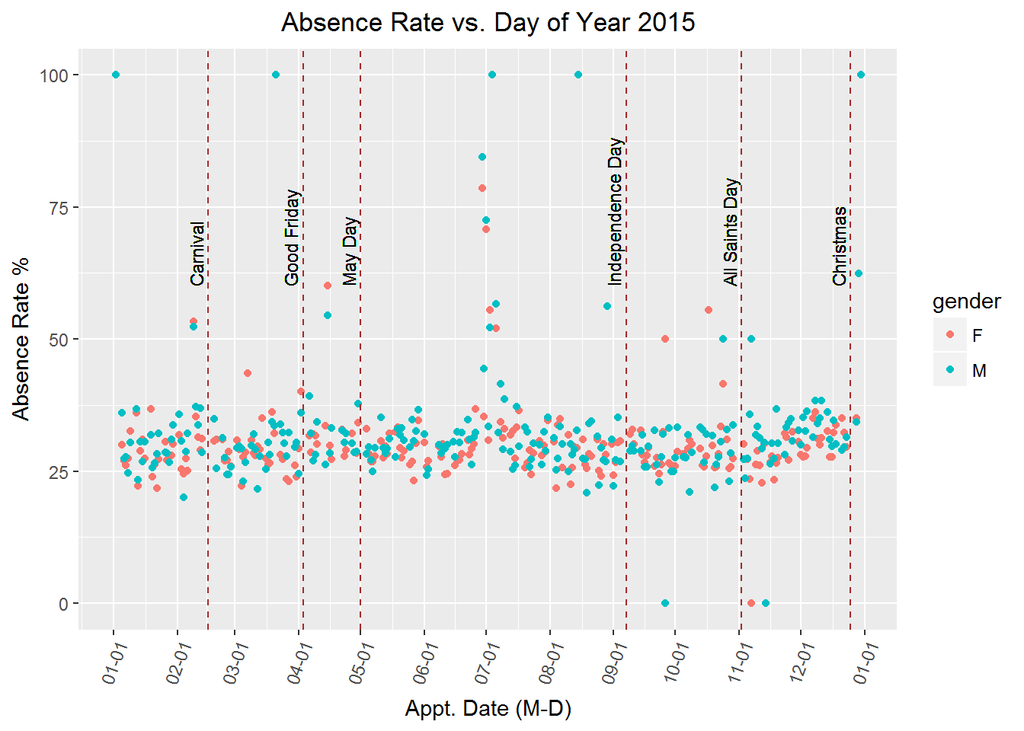

```r
# First for the 2015 plot
ggplot(aes(x = appt_date, y = 100*status), data = subset(no_shows, appt_year == 2015)) +                  geom_point(aes(color = gender),stat = 'summary', fun.y = mean)  +
  labs(x = 'Appt. Date (M-D)', y = 'Absence Rate %', title = 'Absence Rate vs. Day of Year 2015') +     scale_x_date(date_breaks = "1 month", date_labels = "%m-%d") +
  theme(axis.text.x  =element_text(angle = 70, hjust = 1)) +
  geom_vline(aes(xintercept=(as.numeric(as.Date("2015-12-25")))), linetype = 2, color = 'brown') +
  geom_text(aes(x=(as.Date("2015-12-25")), y= 60, label='Christmas'), size=3, angle=90,        vjust=-0.4, hjust=0) +
  geom_vline(aes(xintercept=(as.numeric(as.Date("2015-11-02")))), linetype = 2, color = 'brown') +
  geom_text(aes(x=(as.Date("2015-11-02")), y= 60, label='All Saints Day'), size=3, angle=90,        vjust=-0.4, hjust=0) +
  geom_vline(aes(xintercept=(as.numeric(as.Date("2015-05-01")))), linetype = 2, color = 'brown') +
  geom_text(aes(x=(as.Date("2015-05-01")), y= 60, label='May Day'), size=3, angle=90,        vjust=-0.4, hjust=0) +
  geom_vline(aes(xintercept=(as.numeric(as.Date("2015-09-07")))), linetype = 2, color = 'brown') +
  geom_text(aes(x=(as.Date("2015-09-07")), y= 60, label='Independence Day'), size=3,  angle=90, vjust=-0.4, hjust=0) +
  geom_vline(aes(xintercept=(as.numeric(as.Date("2015-02-16")))), linetype = 2, color = 'brown') +
  geom_text(aes(x=(as.Date("2015-02-16")), y= 60,label='Carnival'), size=3, angle=90,     vjust=-0.4, hjust=0) +
  geom_vline(aes(xintercept=(as.numeric(as.Date("2015-04-03")))), linetype = 2, color = 'brown') +
  geom_text(aes(x=(as.Date("2015-04-03")), y=60, label='Good Friday'), size=3, angle=90,        vjust=-0.4, hjust=0)
```

Again, it seems as if these holidays do not line up with higher rates of missed appointments. There is a sustained increase in the absence rate around the beginning of July, but it does not seem to correspond to any holidays. I researched festivals in Brazil in June-July 2015, and it appears that the [Paraty International Literary Festival](http://www.telegraph.co.uk/travel/destinations/south-america/brazil/articles/brazil-events/) occured July 1-5, but I doubt that this explains the absence rate. There was not city data associated with the original dataset, so it is difficult to attempt to cross-reference specific dates with specific events. I will create a simliar graph for 2014. I remember that the [2014 soccer World Cup was held in Brazil](http://www.fifa.com/worldcup/archive/brazil2014/), so perhaps the time around the world cup will have a higher absence rate. I will plot a few holidays and then the dates surrounding the World Cup (which lasted for a month).

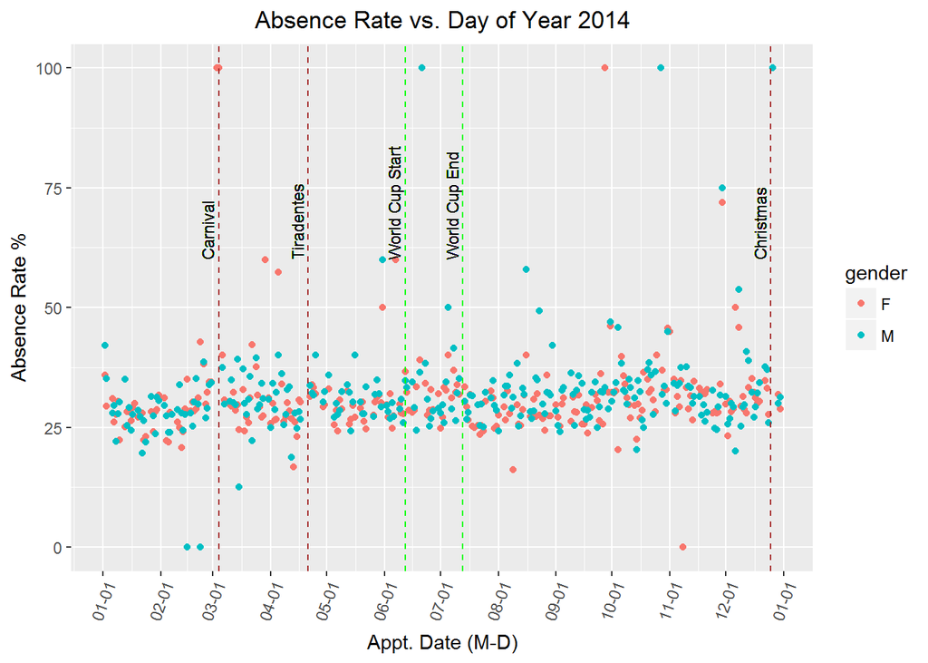

```r
ggplot(aes(x = appt_date, y = 100*status), data = subset(no_shows, appt_year == 2014)) +                  geom_point(aes(color = gender),stat = 'summary', fun.y = mean)  +
  labs(x = 'Appt. Date (M-D)', y = 'Absence Rate %', title = 'Absence Rate vs. Day of Year 2014') +     scale_x_date(date_breaks = "1 month", date_labels = "%m-%d") +
  theme(axis.text.x  =element_text(angle = 70, hjust = 1)) +
  geom_vline(aes(xintercept=(as.numeric(as.Date("2014-12-25")))), linetype = 2, color = 'brown') +
  geom_text(aes(x=(as.Date("2014-12-25")), y=60, label='Christmas'), size=3, angle=90,    vjust=-0.4, hjust=0) +
  geom_vline(aes(xintercept=(as.numeric(as.Date("2014-06-12")))), linetype = 2, color = 'green') +
  geom_text(aes(x=(as.Date("2014-06-12")), y=60, label='World Cup Start'), size=3, angle=90,vjust=-0.4, hjust=0) +
  geom_vline(aes(xintercept=(as.numeric(as.Date("2014-07-13")))), linetype = 2, color = 'green') +
  geom_text(aes(x=(as.Date("2014-07-13")), y=60, label='World Cup End'), size=3, angle=90,vjust=-0.4, hjust=0) +
  geom_vline(aes(xintercept=(as.numeric(as.Date("2014-04-21")))), linetype = 2, color = 'brown') +
  geom_text(aes(x=(as.Date("2014-04-21")), y=60, label='Tiradentes'), size=3,   angle=90, vjust=-0.4, hjust=0) +
  geom_vline(aes(xintercept=(as.numeric(as.Date("2014-03-04")))), linetype = 2, color = 'brown') +
  geom_text(aes(x=(as.Date("2014-03-04")), y=60, label='Carnival'), size=3, angle=90, vjust=-0.4, hjust=0)
```

Perhaps there is a slight increase in absence rate during the World Cup? The graph does not clearly indicate either was but I can compare the average absence rate during the World Cup to the average absence rate over the entire length of 2014.

```r
# Calculate mean absence rate during the world cup and for the entire year
100 * mean(no_shows$status[no_shows$appt_year==2014])
```

```
## [1] 30.08656
```

```r
100 * mean(no_shows$status[no_shows$appt_date < "2014-07-13" & no_shows$appt_date > "2014-06-12"])
```

```
## [1] 30.79473
```

There is a small boost, but not a significant rise in the absence rate during the World Cup. It looks like in terms of time variability, there is no significant correlation based on the day of the year or the day of the month. There is one more time variation I want to look at, and that is day of the week. To remind myself of the small sample sizes on the weekend, I also show the appointment days of the week count.

```r
table(no_shows$weekday)
```

```
##
##    Friday    Monday  Saturday    Sunday  Thursday   Tuesday Wednesday
##     52769     59297      1393         6     60260     62773     63495
```

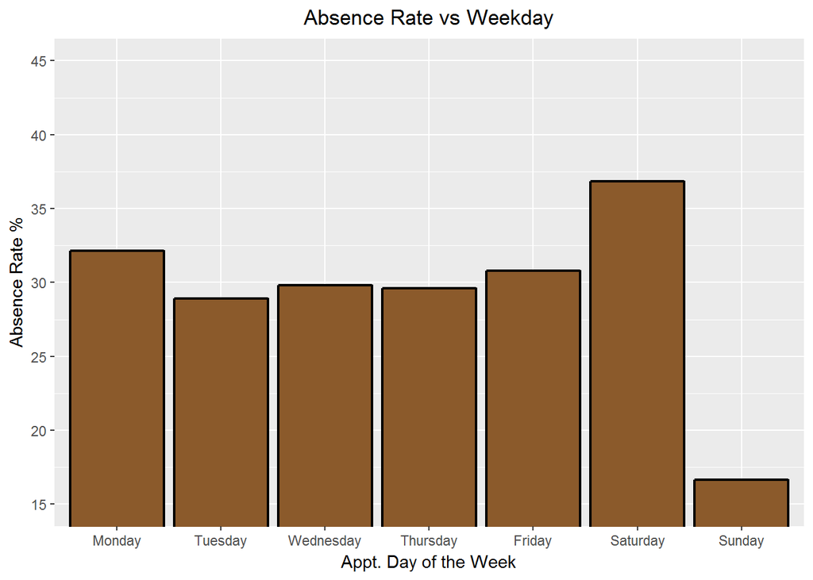

```r
ggplot(aes(x = factor(weekday, weekdays(as.Date('1970-01-03') + 2:8)), y= 100*status), data = no_shows)+  geom_bar(stat= 'summary', fun.y = mean, color = 'black', fill = 'tan4', lwd = 0.8) +
  labs(x='Appt. Day of the Week', y = 'Absence Rate %', title = 'Absence Rate vs Weekday') +
  scale_y_continuous(breaks = seq(015, 045, 05)) + coord_cartesian(ylim=c(15,45))
```

Finally, it looks like there might be some time variability in this data when it is broken down by weekday. Excluding Saturday and Sunday because of their small sample sizes, Monday and Friday have the highest absence rate and Tuesday has the lowest. I will alter the plot to show the absence rate as a relative percentage change from the overall mean absence rate.

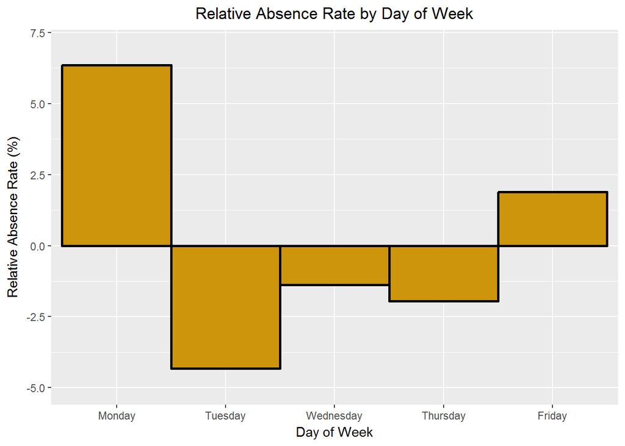

```r
days_of_week = c('Monday', 'Tuesday', 'Wednesday', 'Thursday', 'Friday')

# Find mean absence rate of weekdays
weekday_mean = mean(no_shows$status[no_shows$weekday %in% days_of_week])

# Create a new dataframe with statistics for weekdays only
no_shows_by_weekday <- group_by(no_shows, weekday)
no_shows_by_weekday <- summarise(no_shows_by_weekday,
                                absence_rate = mean(status),
                                relative_absence_rate = 100*  (mean(status) - weekday_mean) / weekday_mean,
                                n = n())

no_shows_by_weekday <- filter(no_shows_by_weekday, weekday %in% days_of_week)

# Plot relative absence rate compared to mean by day of the week
ggplot(aes(x = factor(weekday, weekdays(as.Date('1970-01-03') + 2:6)),
           y= relative_absence_rate) , data = no_shows_by_weekday) +
  geom_bar(stat='identity', color='black', lwd= 1, fill = 'darkgoldenrod3', width = 1) + labs(x='Day of Week', y= 'Relative Absence Rate (%)', title ='Relative Absence Rate by Day of Week') + coord_cartesian(ylim=c(-5,7))
```

Based on this chart, patients are **6% more likely to miss an appointment on a Monday** compared to the average, and **4% less likely to miss an appointment on a Tuesday**. This is an actionable discovery for both patients and doctors! If patients want to keep their appointments, and if doctors want to make sure their patients show up, they should schedule their appointments during the middle three days of the week.

### Patient Age

I wanted to move on from the time variability and look at the demographic data. In particular, I am interested in whether or not age is correlated with absence rate. My initial guess would be that the youngest and the oldest patients would tend to have lower absence rates. Meanwhile, those patients in the middle would generally be healthier and thus would feel more inclined to skip an appointment. (Everyone is convinced they are invincible in their 20s. In fact, this was one of the issues associated with the intial rollout of Obamacare. Too many young, healthy individuals [did not believe they needed insurance](https://www.usnews.com/news/articles/2016-09-07/young-invincibles-remain-elusive-for-obamacare) and therefore did not sign up for healthcare.)

First I will group patients by age and then visualize the average absence rates.

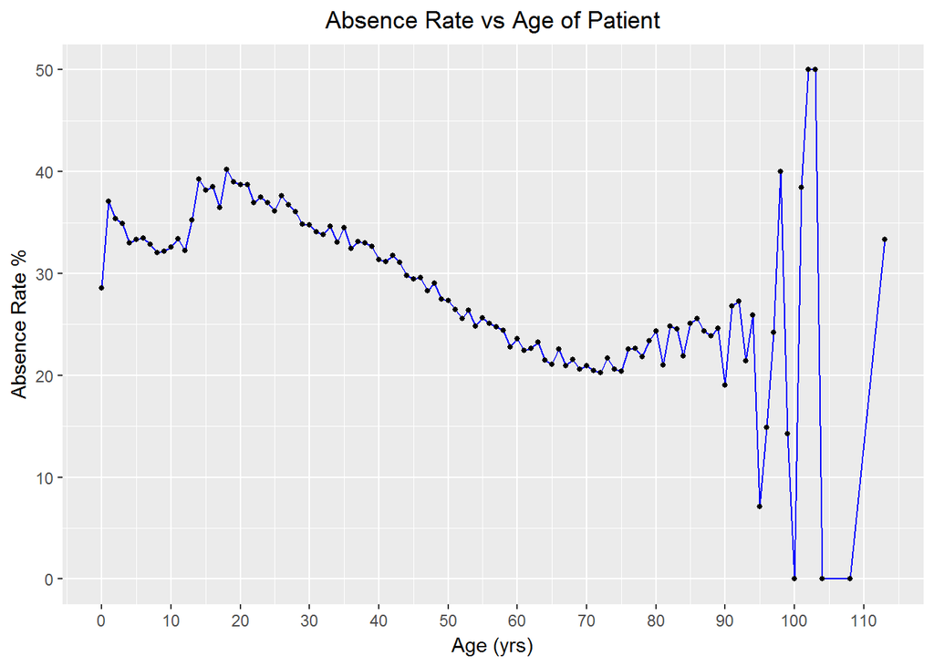

```r
# Create new dataframe grouping patients by age and summarize
no_shows_by_age<-group_by(no_shows, age)
no_shows_by_age <- dplyr::summarize(no_shows_by_age,
                             absence_rate = mean(status),
                             n = n())

# Create a scatter graph of the data by age
ggplot(aes(x = age, y = 100*absence_rate), data = no_shows_by_age) + geom_line(color='blue') +
  geom_point(size = 1) +  labs(x = 'Age (yrs)', y = 'Absence Rate %' , title = 'Absence Rate vs Age of Patient') +   scale_x_continuous(breaks=seq(0,110,10))
```

The chart reveals the possibility of a negative relationship between age and absence rate. First though, it is clear that the outliers in the upper end of the data introduce substantial variance. As there are only 719 patients over 90 out of 300000 entries, I think I can filter out any ages over 90 without impacting the validating of the data while reducing the noise. I will use that filter and then improve the aesthetics of the graph.

```r
# Find number of patients over 90, filter out those patients
nrow(subset(no_shows, age > 90))
```

```
## [1] 719
```

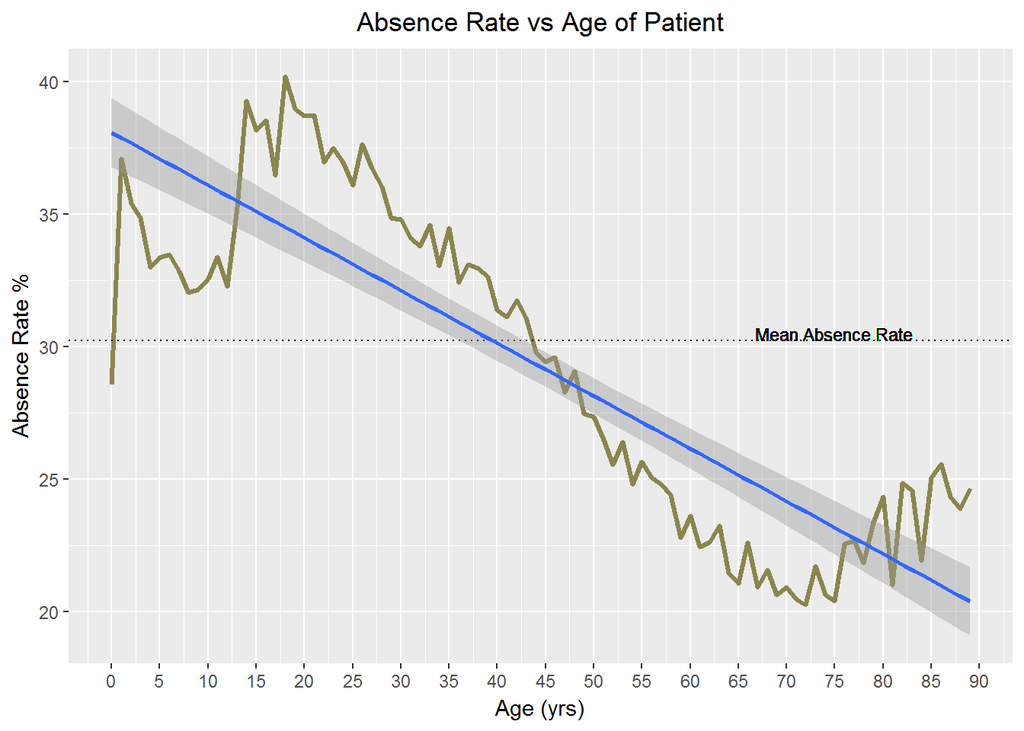

```r
no_shows_by_age <- filter(no_shows_by_age, age < 90)

# Create better plot of absence rate vs age
ggplot(aes(x = age, y = 100 *absence_rate), data = no_shows_by_age) + geom_line(color='khaki4', lwd = 1.2) + scale_x_continuous(breaks=seq(0,90,5)) + geom_hline(aes(yintercept=100*mean(no_shows$status)), linetype = 3, color='black') + labs(x = 'Age (yrs)', y = 'Absence Rate %' , title = 'Absence Rate vs Age of Patient') +  geom_text(aes(x = 75, y= 30.5, label='Mean Absence Rate'), size=3) + geom_smooth(method='lm')
```

```r
# Find maximum and minimum absence rate at age and the correlation between missed vists and age
no_shows_by_age[no_shows_by_age$absence_rate == max(no_shows_by_age$absence_rate),]
```

```
## # A tibble: 1 × 3
##     age absence_rate     n
##   <int>        <dbl> <int>
## 1    18    0.4020537  3798
```

```r
no_shows_by_age[no_shows_by_age$absence_rate == min(no_shows_by_age$absence_rate),]
```

```
## # A tibble: 1 × 3
##     age absence_rate     n
##   <int>        <dbl> <int>
## 1    72    0.2024752  2020
```

```r
cor.test(no_shows_by_age$age, no_shows_by_age$absence_rate)
```

```
##
##  Pearson's product-moment correlation
##
## data:  no_shows_by_age$age and no_shows_by_age$absence_rate
## t = -15.728, df = 88, p-value < 2.2e-16
## alternative hypothesis: true correlation is not equal to 0
## 95 percent confidence interval:
##  -0.9049699 -0.7927363
## sample estimates:
##        cor
## -0.8588338
```

Here are more actionable conclusions. Public health officials need to work on getting teenagers to show up to their appointments! This is expecially crucial because [studies have shown](http://www.tandfonline.com/doi/abs/10.1080/01926187.2014.935684) that habits form very early and are hard to change later in life. A trend of going to the doctor while younger will likely persist as a patient ages and lead to better lifelong health.

We can further bin the data in five years increments to highlight the “problem years”, that is, the years with the highest missed appointment rate. I will plot the relative absence rate, or the average age group absence rate as a percentage relative to the average absence rate for all ages. Remember, in this plot, below the x-axis is better because it indicates that the age group has a lower rate of missed appointments than the average.

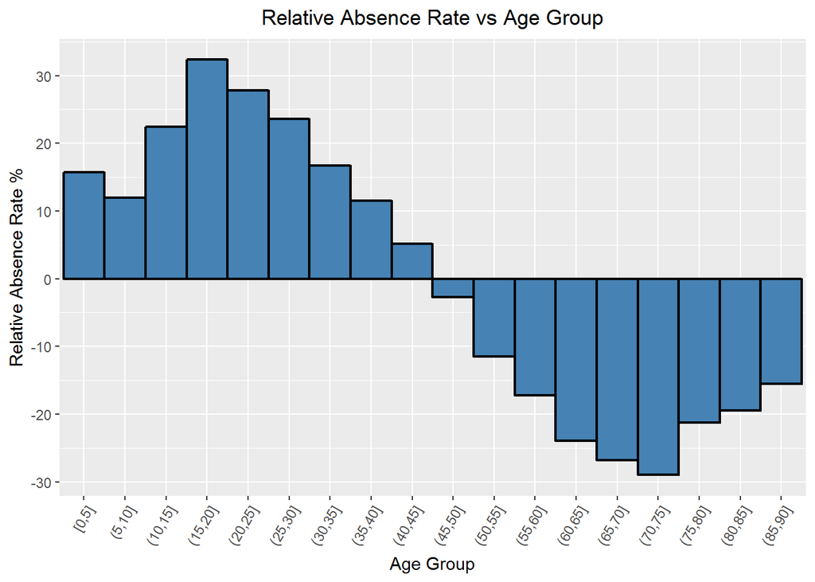

```r
# Cut the data into 5 year bins
no_shows_by_age$age_bucket <- cut(no_shows_by_age$age, breaks= seq(0,90, 5), include.lowest=TRUE)

# Create a new data frame out of the grouping and summarize
no_shows_by_age_bucket <- group_by(no_shows_by_age, age_bucket)
no_shows_by_age_bucket <- dplyr::summarize(no_shows_by_age_bucket,
                                           absence_rate = mean(absence_rate),
                                           n = n())

# Add a field with the percentage absence rate relative to the mean
no_shows_by_age_bucket$relative_absence_rate <- with(no_shows_by_age_bucket, 100 *(absence_rate - mean(absence_rate)) / mean(absence_rate))

# Plot the dataframe as a barplot
ggplot(aes(x = age_bucket, y = relative_absence_rate), data= no_shows_by_age_bucket) +
  geom_bar(stat='identity', color='black', fill = 'steelblue', lwd = 0.8, width=1) +
  theme(axis.text.x=element_text(angle = 60, hjust=1)) + labs(x = 'Age Group', y = 'Relative Absence Rate %', title = 'Relative Absence Rate vs Age Group') + scale_y_continuous(breaks=seq(-40, 40, 10))
```

Based on the chart, is it clear that the worst group in terms of absence rate is 15-20 year-olds and the best group for attedance is 70-75 year-olds. The visualization and the statistics are definitive when it comes to ages and missed appointments. The correlation between ages and absence rate is -0.86, which is strongly negative and indicates that as the age of the patient increases, statistically, that patient is less likely to miss a scheduled doctor’s appointment.

### Waiting Time

After finding a strong relationship between age and absence rate, I will move on to examine other variables. I would like to search for a possible trend in absence rate by waiting time, or the time between when an appointment was scheduled, and when the appointment took place. My hypothesis is that patients with a longer waiting time will have a higher missed appointment rate because their condition has more time to change in the interim period. Moreover, I think that patients with a shorter waiting time are more likely to need urgent care or have a problem they deem to be pressing, and it would certainly be in their best interest to show up at the appointment.

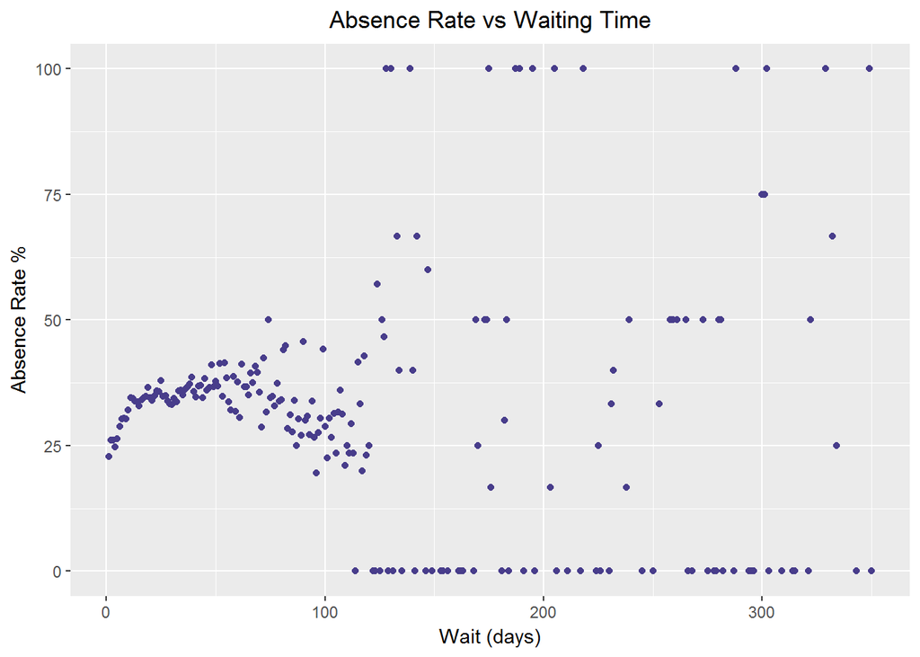

```r
# Create a new dataframe grouping by waiting time and summarize
no_shows_by_wait <- group_by(no_shows, wait)
no_shows_by_wait <- dplyr::summarize(no_shows_by_wait,
                                     absence_rate = mean(status),
                                     n = n())

# Plot the absence rate vs waiting time
ggplot(aes(x = wait, y = 100 * absence_rate), data = no_shows_by_wait) + geom_point(color='darkslateblue') +
  labs(x = 'Wait (days)' , y = 'Absence Rate %', title = 'Absence Rate vs Waiting Time')
```

```r
cor.test(no_shows_by_wait$absence_rate, no_shows_by_wait$wait)
```

```
##
##  Pearson's product-moment correlation
##
## data:  no_shows_by_wait$absence_rate and no_shows_by_wait$wait
## t = -0.75865, df = 210, p-value = 0.4489
## alternative hypothesis: true correlation is not equal to 0
## 95 percent confidence interval:
##  -0.18572082  0.08305389
## sample estimates:
##         cor
## -0.05228019
```

The graph and the correlation coefficient seem to demonstrate a lack of any relationship. However, thinking back on the histogram of waiting time from the initial exploration, the majority of the patients waited under 100 days. There are far fewer data points from people waiting more than 100 days, which is why the average absence rate for those times tends to be either 0% or 100%. If I limit the data to people with a waiting time less than 3 months (90 days), might there exist a relationship? Furthermore, I will group the data into 10 day segments.

```r
# Check to see how many people had a waiting time over 90 days.
nrow(subset(no_shows, wait > 90))
```

```
## [1] 1646
```

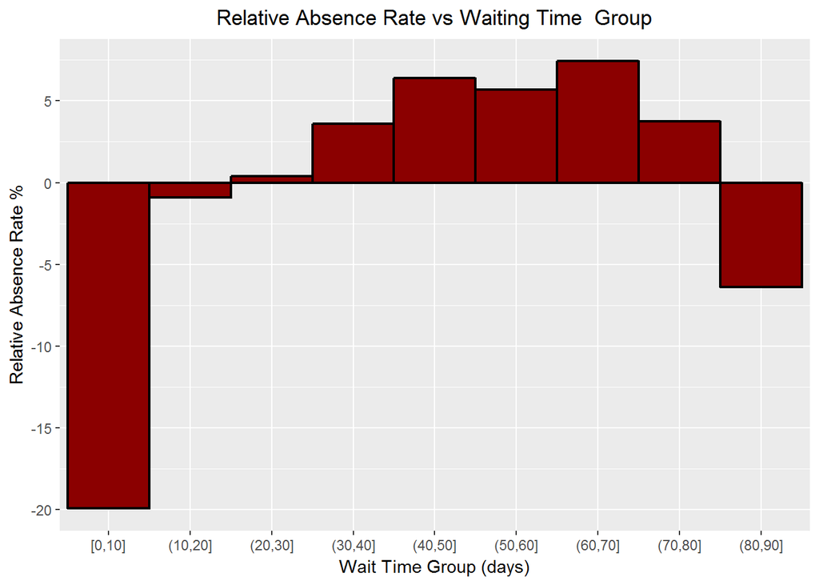

```r
# Limit data to those with a waiting time less than 90 days (3 months)
no_shows_by_wait <- filter(no_shows_by_wait, wait< 90)

# Cut the data into bins of 10 days
no_shows_by_wait$wait_bucket <- cut(no_shows_by_wait$wait, breaks = seq(0,90,10), include.lowest = TRUE)

# Create a new dataframe grouping by wait bucket and summarize
no_shows_by_wait_bucket <- group_by(no_shows_by_wait, wait_bucket)
no_shows_by_wait_bucket <- dplyr::summarize(no_shows_by_wait_bucket,
                                           absence_rate = mean(absence_rate),
                                           n = n())

# Calculate the absence rate for each bucket relative the mean absence rate
no_shows_by_wait_bucket$relative_absence_rate <- with(no_shows_by_wait_bucket, 100 *(absence_rate - mean(absence_rate)) / mean(absence_rate))

# Graph the relative absence rate for each age bucket
ggplot(aes(x = wait_bucket, y = relative_absence_rate), data = no_shows_by_wait_bucket) +
  geom_bar(stat='identity', color='black', fill='red4', lwd = 0.8, width = 1) +
  scale_y_continuous(breaks=seq(-30, 20, 5)) +
  labs(x = 'Wait Time Group (days)', y = 'Relative Absence Rate %', title = 'Relative Absence Rate vs Waiting Time  Group')
```

```r
cor.test(no_shows_by_wait$absence_rate, no_shows_by_wait$wait)
```

```
##
##  Pearson's product-moment correlation
##
## data:  no_shows_by_wait$absence_rate and no_shows_by_wait$wait
## t = 2.8438, df = 87, p-value = 0.005556
## alternative hypothesis: true correlation is not equal to 0
## 95 percent confidence interval:
##  0.08876595 0.47126629
## sample estimates:
##       cor
## 0.2916315
```

If the data is limited to those patients who scheduled fewer than 3 months in advance, there is a slight postive coorelation between waiting time and absence rate. I tried to do some research on this subject in general, and found this from the [Safety Net Dental Clinic](https://www.dentalclinicmanual.com/chapt4/6_3.html): “Experience in many safety net dental programs also suggests that the incidence of broken appointments increases when appointments are scheduled more than three weeks in advance.” Based on my analysis, I concur. Patients who schedule less than 10 days out are **20%** less likely to miss an appointment than those scheduling further out. The Safety Net Dental Clinic page mentions that often other life events get in the way when we schedule too far out, and although that may be a slightly different situation, the general pattern appears to hold in this case. Add a point to schedule as few days out as possible to the list of recommendations for patients looking to adhere to a scheduled appointment.

### SMS Reminders

One of the most intriguing aspects of the dataset to me was the SMS text message reminder counts. Text message reminders have been implemented in many clinics because of their ease of use and low cost. Moreover, they have been shown to be effective in [some situations](https://www.mja.com.au/journal/2005/183/7/use-sms-text-messaging-improve-outpatient-attendance?inline=true). I want to examine this data to discover how or if SMS messages correlate with a failure to attend. I would think that patients who recieve SMS messages will be more likely to attend the appointment than those not receiving them. However, this could be complicated by the fact that younger patients are more likely to sign up for text message alerts, and as we have already seen, young individuals are more inclined to be record a no-show. Therefore, I will probably need to further look at who exactly is recieving the text messages in addition to the correlation between text messages and attendance at the appointment.

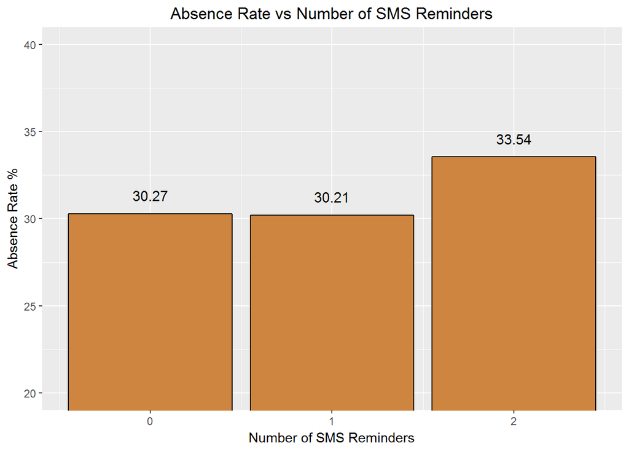

```r
no_shows_by_sms <- group_by(no_shows, sms_reminder)
no_shows_by_sms <- dplyr::summarize(no_shows_by_sms,
                                    absence_rate = mean(status),
                                    n = n())
ggplot(aes(x = sms_reminder, y = 100 * absence_rate), data = no_shows_by_sms) +
  geom_bar(stat='identity', color='black', fill='peru') +
  labs(x = 'Number of SMS Reminders', y = 'Absence Rate %' , title = 'Absence Rate vs Number of SMS Reminders') +     geom_text(aes(label = sprintf("%0.2f", 100 *absence_rate), y = 100* absence_rate + 2.6), size = 4, hjust = 0.5, vjust =   3) + coord_cartesian(ylim=c(20,40)) + scale_y_continuous(breaks=seq(020, 040, 05))
```

The grah is somewhat surprising to me; one text message seems to decrease the absence rate while two increases it siginificantly. I would have expected more SMS reminders to be strongly correlated with a decrease in absence rate. Maybe the direction of this relationship is the opposite of what I thought. Instead of SMS messages persuading patients to attend a scheduled appointment, patients who are least likely to attend an appointment recieve more text messages. One way to check for this would be to look at average SMS messages per appointment recieved by age. I expect there might be odd behavior at the ends of this graph (how young do children recieve their first phone nowadays? Has the average 80-year old embraced text messages?). I expect that segmenting by age might reveal more nuances than the overall absence rate vs text messages.

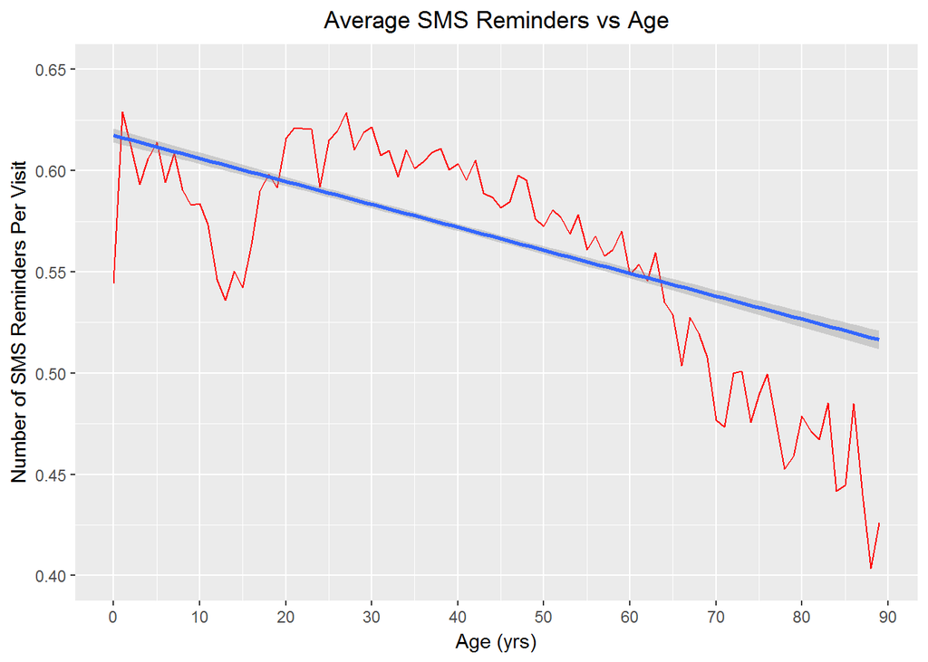

```r
# Graph the average text messages received by age and linear trend line
ggplot(aes(x = age, y = sms_reminder), data = subset(no_shows, age < 90)) + geom_line(stat='summary', fun.y = mean, color='red') + labs(x = 'Age (yrs)', y = 'Number of SMS Reminders Per Visit', title='Average SMS Reminders vs Age' ) + scale_x_continuous(breaks= seq(0,90, 10)) + geom_smooth(method = 'lm') + coord_cartesian(ylim=c(0.4,0.65))
```

```r
# Create new data frame grouping by ages and summarize
no_shows_by_age_texts <- group_by(no_shows, age)
no_shows_by_age_texts <- filter(no_shows_by_age_texts, age < 90)
no_shows_by_age_texts <- dplyr::summarize(no_shows_by_age_texts,
                                   average_reminders = mean(as.numeric(as.character(sms_reminder))),
                                   absence_rate = mean(status),
                                   n = n())

# Find correlation coefficient between average number of reminders and age
cor.test(no_shows_by_age_texts$average_reminders, no_shows_by_age_texts$age)
```

```
##
##  Pearson's product-moment correlation
##
## data:  no_shows_by_age_texts$average_reminders and no_shows_by_age_texts$age
## t = -12.39, df = 88, p-value < 2.2e-16
## alternative hypothesis: true correlation is not equal to 0
## 95 percent confidence interval:
##  -0.8620345 -0.7068951
## sample estimates:
##        cor
## -0.7972722
```

Sure enough, the number of SMS reminders per appointment is higher among the younger ages. I looked through the data provider information, and I could not ascertain whether or not those SMS reminders were to the parent in the case of a very young child but that seems likely. From the statistics and the plot, there is a strong negative correlation between the number of SMS messages and the age of the patient. To further explore the absence rate vs text message, I will recreate the absence rate vs age graph, but this time, create separate curves for number of SMS reminders received.

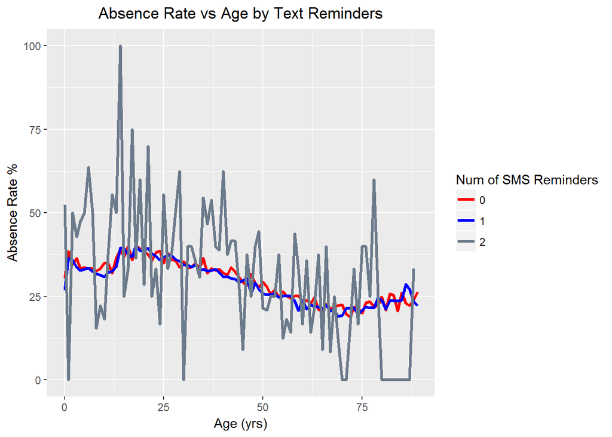

```r
# Create new data frame grouping by ages and summarize
no_shows_by_texts <- group_by(no_shows, age)
no_shows_by_texts <- filter(no_shows_by_texts, age < 90)

# Make SMS reminder field a factor for graphical sorting
no_shows_by_texts$sms_reminder <- factor(no_shows_by_texts$sms_reminder)

# Create plot of absence rate vs age by number of sms reminders
ggplot(aes(x = age, y = 100 * status), data = no_shows_by_texts) + geom_line(aes(color=sms_reminder), stat = 'summary', fun.y = mean, lwd = 1.2) + labs(x = 'Age (yrs)', y = 'Absence Rate %', title='Absence Rate vs Age by Text Reminders' ) + scale_color_manual(name='Num of SMS Reminders', values=c('red','blue', 'slategray4'))
```

Looking at the graph, we can see that the absence rate versus age grouped by number of SMS reminders looks much the same for the 0 or 1 reminders. However, the graph for 2 reminders is much noisier. I suspect that is due to the lower sample size of people receiving two reminders (which was the maximum). In order to determine if there is an effect from text message reminders at a given age, I need to create a plot showing the difference in absence rates at each age between those receiving any reminder and those receiving no reminder.

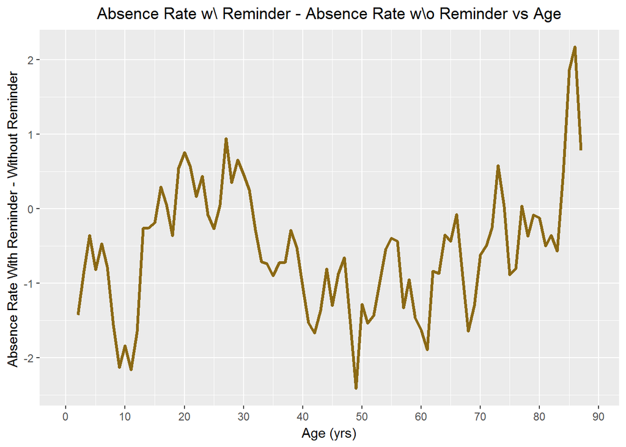

```r
# Create two new dataframes with no reminders and with reminders
no_shows_no_reminder <- no_shows[no_shows$sms_reminder == 0 & no_shows$age < 90,]
no_shows_with_reminder <- no_shows[no_shows$sms_reminder > 0 & no_shows$age < 90 ,]

# Group the data frames and summarize
no_shows_no_reminder <- group_by(no_shows_no_reminder, age)
no_shows_with_reminder <- group_by(no_shows_with_reminder, age)

no_shows_no_reminder <- dplyr::summarize(no_shows_no_reminder,
                                  absence_rate_no_reminder = mean(status))
no_shows_with_reminder <- dplyr::summarize(no_shows_with_reminder,
                                    absence_rate_with_reminder = mean(status))

# Merge the two dataframes into a single dataframe
no_shows_reminder <- merge(no_shows_no_reminder, no_shows_with_reminder, by = 'age')

# Add column with difference in absence rate between those receiving no messages and those with 1 or 2
no_shows_reminder <- transform(no_shows_reminder, diff = absence_rate_with_reminder - absence_rate_no_reminder)

# Load in zoo library for rolling mean
suppressMessages(library(zoo))

# Create rolling mean with a window of 5 years to smooth data
no_shows_reminder$diff <- rollmean(no_shows_reminder$diff, 5, fill = NA)

# Graph the difference column as a line graph
ggplot(aes(x = age, y = 100 * diff), data = no_shows_reminder) + geom_line(color = 'goldenrod4', lwd = 1.2) + labs(x='Age (yrs)' , y = 'Absence Rate With Reminder - Without Reminder ', title = 'Absence Rate w\\ Reminder - Absence Rate w\\o Reminder vs Age') + scale_x_continuous(breaks=seq(0,90,10))
```

```r
100 * mean(no_shows_reminder$diff)
```

```
## [1] NA
```

### Patient Markers

The final step in this analysis is to look at the absence rate by the condition for which the patient visited the doctor. I will group by the markers in the original data and then look at each average absence rate.

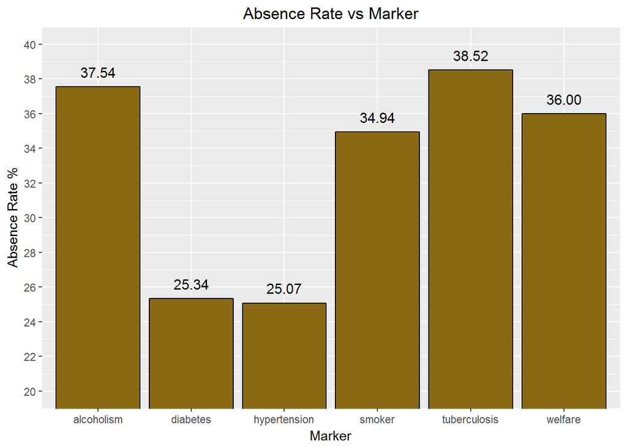

```r
# Get names of conditions
conditions = colnames(no_shows[7:12])
absence_rates <- c(0,0,0,0,0,0)

# Create new dataframe with fields for condition, counts of condition, and absence rate
no_shows_by_condition <- data.frame(absence_rate = c(0,0,0,0,0,0), counts = c(0,0,0,0,0,0), marker =  conditions)

# Loop through the conditions and assign the mean and count to appropriate columns
for (i in seq(1, length(conditions))){
  condition <- conditions[i]
  no_shows_by_condition[i, 1] <- mean(no_shows$status[no_shows[, condition] == 1])
  no_shows_by_condition[i, 2] <- table(no_shows[, condition] == 1)['TRUE']
}

# Plot the absence rate versus the condition the patient was marked for
ggplot(aes(x = marker, y = 100 * absence_rate), data = no_shows_by_condition) + geom_bar(stat='identity', color = 'black', fill = 'goldenrod4') + labs(x='Marker', y= 'Absence Rate %' , title = 'Absence Rate vs Marker') +
  scale_y_continuous(breaks = seq(20, 40, 02)) + coord_cartesian(ylim = c(20,40)) +
  geom_text(aes(label = sprintf("%0.2f", 100 * absence_rate), y = 100 * absence_rate + 2.4), size = 4, hjust = 0.5, vjust = 3)
```

There are considerable differences demonstrated between those with different markers. Tuberculosis has the highest rate of absence, followed by alcoholism. However, these conditions also make up a small sample of the overall visits. Diabeters and hypertension have the lowest absence rate. Interestingly, patients marked as being part of the Bolsa Familia welfare program have a high rate of absences. This program rewards patients for attending appointments, which should induce patients to visit their doctor more often. Perhaps there are other factors at play here though. It could be that families on the welfare program cannot take the time to visit the doctor because of the opportunity cost of not working. To put the conditions in perspective, here is a the percentage of all visits each condition makes up.

```r
no_shows_by_condition$pct_of_vists <- 100 * no_shows_by_condition$counts / nrow(no_shows)
no_shows_by_condition
```

```
##   absence_rate counts       marker pct_of_vists
## 1    0.2533561  23390     diabetes   7.79684859
## 2    0.3754498   7503   alcoholism   2.50105836
## 3    0.2507450  64767 hypertension  21.58950376
## 4    0.3494367  15711       smoker   5.23712220
## 5    0.3599711  29069      welfare   9.68989276
## 6    0.3851852    135 tuberculosis   0.04500105
```

The final plot I can make is of the conditions and the relative percentage difference in absence rates compared to the mean absence rate. Relative difference plots are helpful to me because it is possible to quickly identify if one variable is above or below the average. Again, for this particular plot, values below the x-axis are great because it means the absence rate is lower than the overall average.

```r
# Create the relative absence column
no_shows_by_condition$relative_absence_rate <- 100 * (no_shows_by_condition$absence_rate - mean(no_shows$status)) / mean(no_shows$status)
```

Create the relative absence rate compared to the age versus condition plot.

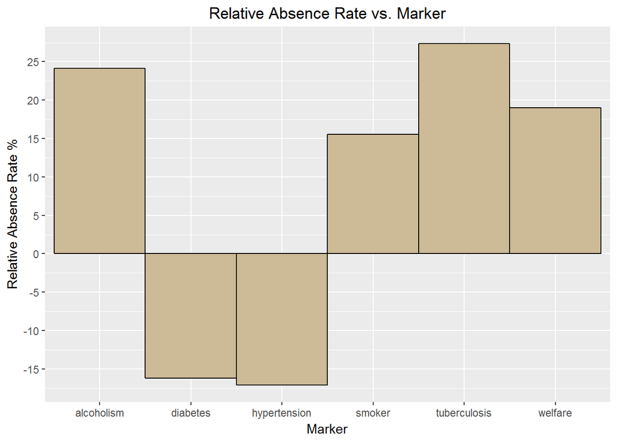

```r
# Create the relative absence plot
ggplot(aes(x = marker, y= relative_absence_rate), data = no_shows_by_condition) +
  geom_bar(stat='identity' , color = 'black', fill= 'wheat3', width = 1) +
  labs(x= 'Marker' , y= 'Relative Absence Rate %' , title= 'Relative Absence Rate vs. Marker') +                    scale_y_continuous(breaks = seq(-20, 40, 5))
```

The differences between conditions here are stark. Again, the smaller sample sizes associated with alcoholism and tuberculosis must be taken into account, but it is clear that patients with diabetes and hypertension are more likely to attend an appointment. In fact, they are more than 15% less likely to miss an appointment then the average patient. This is an interesting result and I wonder if it is because of the constant need for care when treating both of these conditions. However, it would seem like all of the conditions require care on an ongoing basis. I would need more detailed condition information before I drew any conclusions about possible causes of the absence rates broken out by condition.

# Summary of Analysis

I started this project off with a single simple question: what factors are most likely to determine whether or not a patient shows up to their scheduled doctor’s appointment? As the exploratory data analysis went on, I found this one question had branched into dozens. Does the number of SMS reminders correlate with absence rates? How about if we compare SMS reminders for a given age? Are there major variabilities that we can observe associated with holidays? I found my curiousity and interest in the dataset only grew as I delved further and further. Although at first it appeared there were few meaningful relationships, by grouping and segmenting the data, clear trends emerged. Keeping in mind that this dataset may not be representative of all countries and health care systems, the following are the most notable discoveries from the patient no-show data:

These are but a few briefs observations that can be gleaned from this dataset. Keeping in mind that [correlations do not imply causations](https://xkcd.com/552/) ([more serious link for those interested](https://web.cn.edu/kwheeler/logic_causation.html)), and that some of the groupings results in small sample sizes, there are actionable items that with appropriate further study, could be implemented in the health care system.

## Final Three Plots

The final aspect of the project was revisit and refine three of my earlier plots. Primarily I am concerned with whether or not the visualizations correctly convey the information within the dataset. My secondary objective is of course aesthetics because what good is even the most informative chart if it is not presentable?

### Absence Rate vs. Day of the Year

The first chart was notable to me because of the lack of relationships it revealed. It is the graph of absence rate versus day of the year in 2014 with holidays (and the World Cup) included. I would have initially believed that absence rates spiked around holidays and near the end of the year. However, no clear trend emerged from this plot. In order to improve the information content and the aesthetics, I altered some of the colors, changed the scale on the axis, added in the mean absence rate for reference, and made sure all labels were accurate.

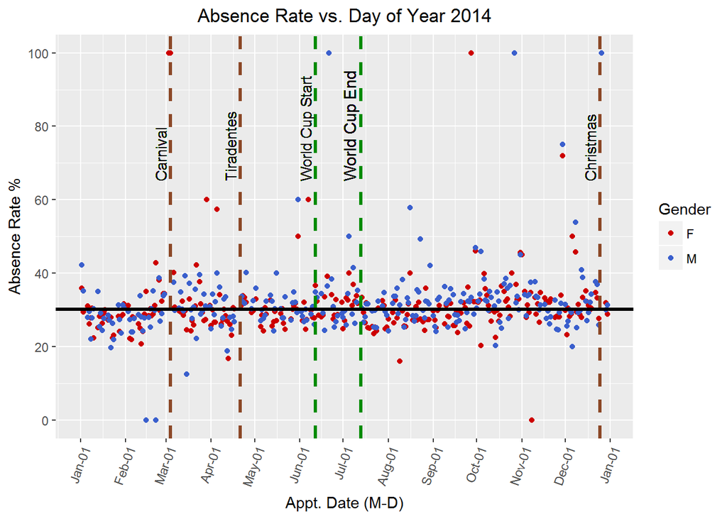

```r
# Calculate the yearly mean
yearly_mean <- 100*mean(no_shows$status[no_shows$appt_year == 2014])

# Create the 2014 plot with improved characteristics
ggplot(aes(x = appt_date, y = 100 * status), data = subset(no_shows, appt_year == 2014)) +                          geom_point(aes(color = gender),stat = 'summary', fun.y = mean)  +
  labs(x = 'Appt. Date (M-D)', y = 'Absence Rate %', title = 'Absence Rate vs. Day of Year 2014') +                 scale_x_date(date_breaks = "1 month", date_labels = "%b-%d")+
  scale_color_manual(name='Gender', values =c('red3','royalblue3')) +
  theme(axis.text.x  =element_text(angle = 70, hjust = 1)) +
  scale_y_continuous(breaks=seq(0,100,20)) + coord_cartesian(ylim=c(0,100)) +
  geom_vline(aes(xintercept=(as.numeric(as.Date("2014-12-25")))), lwd = 1.1, linetype = 2, color = 'sienna4') +
  geom_text(aes(x=(as.Date("2014-12-25")), y=65, label='Christmas'), size=3.6, angle=90, vjust=-0.4, hjust=0) +
  geom_vline(aes(xintercept=(as.numeric(as.Date("2014-06-12")))), lwd = 1.1,  linetype = 2, color = 'green4') +
  geom_text(aes(x=(as.Date("2014-06-12")), y=65,label='World Cup Start'), size=3.6, angle=90,vjust=-0.4, hjust=0)+
  geom_vline(aes(xintercept=(as.numeric(as.Date("2014-07-13")))),lwd = 1.1,  linetype = 2, color = 'green4') +
  geom_text(aes(x=(as.Date("2014-07-13")), y=65,label='World Cup End'), size=4, angle=90, vjust=-0.4, hjust=0)+
  geom_vline(aes(xintercept=(as.numeric(as.Date("2014-04-21")))), lwd = 1.1, linetype = 2, color = 'sienna4') +
  geom_text(aes(x=(as.Date("2014-04-21")), y=65, label='Tiradentes'), size=3.6, angle=90, vjust=-0.4, hjust=0) +
  geom_vline(aes(xintercept=(as.numeric(as.Date("2014-03-04")))), lwd = 1.1, linetype = 2, color = 'sienna4') +
  geom_text(aes(x=(as.Date("2014-03-04")), y=65,label='Carnival'), size=3.6, angle=90, vjust=-0.4, hjust=0) +
  geom_hline(aes(yintercept= yearly_mean), linetype = 1, lwd = 1.2)
```

### Absence Rate vs Age by SMS Reminders

I wanted to take another look at the absence rate versus both age broken out by SMS reminders. The original graph had provided an insight on the data, because when I initially looked at the data showing that overall, people who received 2 text message reminders had higher absences rates, I was a little skeptical. However, after some thought, I realized that people who received text messages were likely to be younger, and I had seen that the younger the patient, the higher the absence rate. Therefore, I decided to look at the effect of text messages reminders at each given age. Using that visualization, I saw that indeed, SMS reminders do reduce the absence rate at a specific age. I plotted this difference, but wanted to refine the graph. To make the point clearer, I plotted the average absence rate vs age for those who received no reminders and for those who did receive reminders. The original graphs were very noisy, so I applied a moving average over 5 years. The 5 year window was a selection based on the [bias-variance tradeoff](http://machinelearningmastery.com/gentle-introduction-to-the-bias-variance-trade-off-in-machine-learning/) because while I wanted a smoother plot, I did not want to introduce a high amount of bias into the averages. After improving the graph, it is possible to observe the trend of fewer absences at older ages and the effectiveness of SMS reminders in reducing the failure to attend rate.

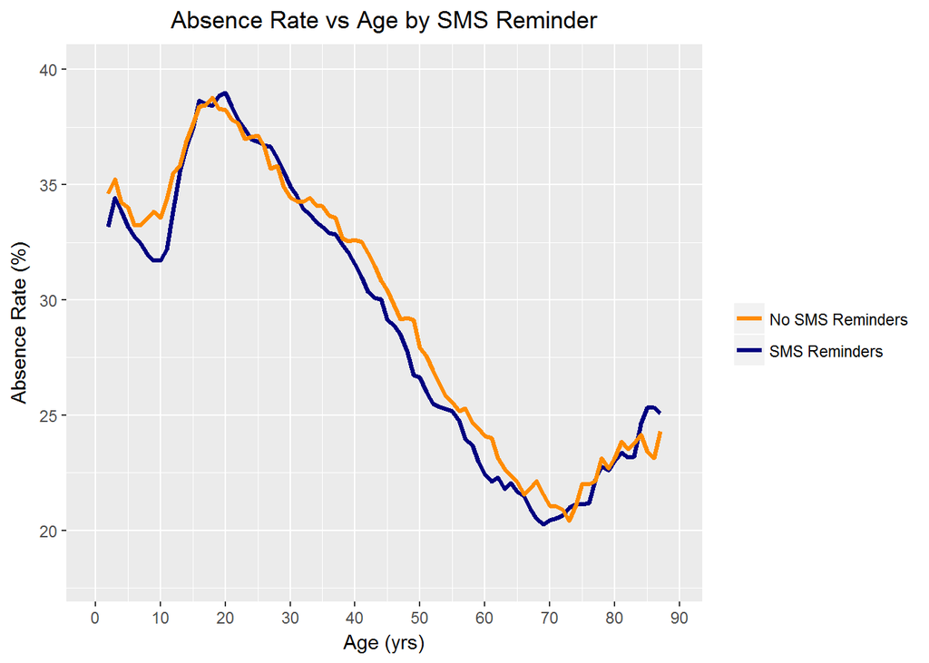

```r
# Take rolling average over 5 years
no_shows_reminder$no_reminder_rolling_mean <- zoo::rollmean(no_shows_reminder$absence_rate_no_reminder, 5, fill = NA)
no_shows_reminder$reminder_rolling_mean <- zoo::rollmean(no_shows_reminder$absence_rate_with_reminder, 5, fill = NA)

# Plot average absence rate versus age by text reminders.
ggplot(aes(x = age), data = no_shows_reminder) +
  geom_line(aes(y = 100*reminder_rolling_mean, color = 'SMS Reminders'), lwd = 1.2) +
  geom_line(aes(y = 100* no_reminder_rolling_mean, color = 'No SMS Reminders') , lwd = 1.2) +
  labs(x='Age (yrs)' , y = 'Absence Rate (%)', title = 'Absence Rate vs Age by SMS Reminder') +                     scale_x_continuous(breaks=seq(0,90,10)) + scale_color_manual(name = '', values = c('darkorange', 'navy')) +
  scale_y_continuous(breaks=seq(15,45,5)) + coord_cartesian(ylim=c(18,40))
```

### Absence Rate vs Waiting Time Group

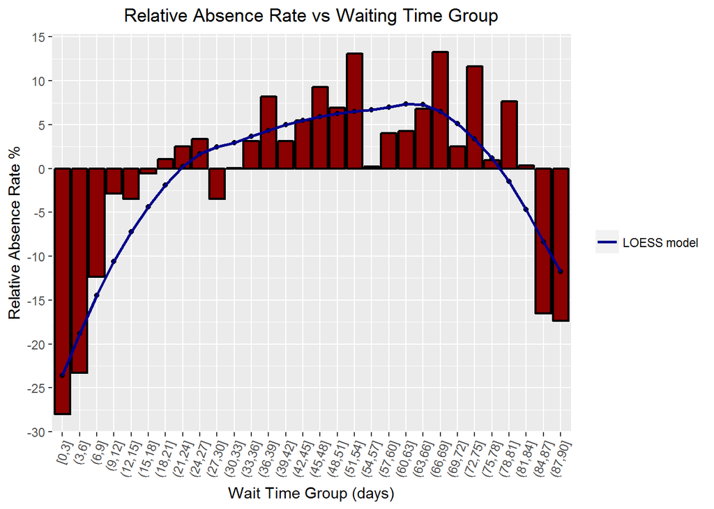

```r
# Create new data frame with waiting times less than 90 days
no_shows_by_wait <- group_by(subset(no_shows, wait < 90), wait)
no_shows_by_wait <- dplyr::summarize(no_shows_by_wait,
                              absence_rate = mean(status))

# Create a relative absence rate compared to the mean column
no_shows_by_wait <- transform(no_shows_by_wait, relative_absence_rate = 100 * (absence_rate - mean(absence_rate ))/ mean(absence_rate))

# Create a model for the relative absence rate based on the input of wait
model <- loess(no_shows_by_wait$relative_absence_rate ~ no_shows_by_wait$wait)

# Use the model to predict absence rates for the range of waiting times
pr <- predict(model, newdata=data.frame(wait=1:89))

# Add the column to the dataframe for plotting
no_shows_by_wait$pr <- pr

# Cut the data into groups of 3 days
no_shows_by_wait$wait_bucket <- cut(no_shows_by_wait$wait, breaks = seq(0,90,3), include.lowest = TRUE)

# Create a new dataframe with the wait bucket and summarize
no_shows_by_wait_bucket <- group_by(no_shows_by_wait, wait_bucket)
no_shows_by_wait_bucket <- dplyr::summarize(no_shows_by_wait_bucket,
                                           absence_rate = mean(absence_rate),
                                           pr = mean(pr),
                                           n = n())

# Find the absence rate relative to the overall average absence rate
no_shows_by_wait_bucket$relative_absence_rate <- with(no_shows_by_wait_bucket, 100 *(absence_rate - mean(absence_rate)) / mean(absence_rate))

# Plot the relative absence rate vs waiting time and the LOESS model prediction
ggplot(aes(x = wait_bucket, y = relative_absence_rate), data = no_shows_by_wait_bucket) +
  geom_bar(stat='identity', color='black', fill='red4', lwd = 0.8) + scale_y_continuous(breaks=seq(-30, 20, 5)) +
  labs(x = 'Wait Time Group (days)', y = 'Relative Absence Rate %', title = 'Relative Absence Rate vs Waiting Time Group') + theme(axis.text.x = element_text(angle = 70, hjust = 1)) + geom_point(aes(y= pr)) + geom_line(aes(x = wait_bucket, y = pr, color='LOESS model'), group = 1, lwd = 1) + scale_color_manual(name='', values = 'darkblue')
```

## Reflections

The primary reason I felt I needed to learn the tools of data analysis was so I could extract meaningful information from the mounds of data generated in our modern world. I want to be able to take hundreds of thousands or even millions of data points and extract insights which can be implemented in the real world to improve systems. Exploring the patient no-show dataset has been a small step towards developing that ability. Although the sheer amount of data appeared overwhelming at first, and there were no correlations that immediately stood out, by selectively grouping the data and adjusting the visualization parameters, I was able to discover several key relationships. The main difficulty I had was intially beginning the analysis. With so many variables, it was a struggle to decide where I should head first. However, once I started grouping the data, I found more and more directions I could in until I felt that I was satisfied with the extent to which I had unravelled the data. R is a tricky language to pick up, but once I understood the patterns and syntax, I enjoyed the level of control it gave me over the visualizations. I was frustrated at times with trying to perfect parameters of a graph, but in the end, I think I am a better data analyst for having to work through all the intricacies of the R language. The next step forward, now that the exploratory data analysis is complete, would be to perform confirmatory data anaylsis on the dataset. Based on my initial observations, I could form several hypotheses and then use rigorous statistical methods to test those hypothesis. Exploratory data analysis can discover potential relationships, but it takes testing to determine whether these correlations are statistically meaningful. Moreover, this dataset is an ideal candidate for machine learning to create classifiers that would identify patients likely to be a no-show at an appointment. The objective would be to make a model that would take in as input patient demographics and conditions, and would output or return the likelihood that they would fail to attend a scheduled doctor’s appointment. If the model was accuracte enough, it could then be implemented in the real-world by ensuring that patients most likely to miss a doctor’s visit receive additional persuasion. Moreover, with a more complete dataset, including city information or detailed demographics, many more observations could be made such as absence rate correlations with the weather or with access to public transportation. The initial exploratory data analysis of the doctor’s appointment no-show data has revealed numerous potential relationships and the dataset holds actionable information that could be used to improve patient outcomes and public health.